# 120 Years of Olympic History

A.J. Lozano 4/15/2019

### DF Olympic Interests:

All types of good stuff!!!.

Obviously, the best medal you can earn is a gold and the worst(even though it's an incredible accomplishment) is a bronze. Silver lands right in the middle.

# Univariate Data Exploration

Medal Exploration

Bling Baby!!!

What does the medal count in our data set consist of?

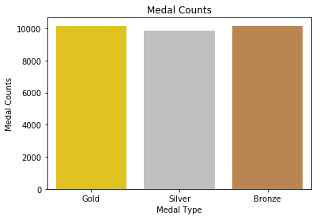

```python
# Lets take a look at our main topic area...Bling Baby!!!

base_color = sns.color_palette()[0]

color = ['gold', 'silver', 'peru']
#normally we would want colors to be uniform, but I could't pass up the chance to color coordinate.

medal_order = df2['Medal'].value_counts().index

medal_plot = sns.countplot(data = df2, x = 'Medal',  palette = color);
plt.title("Medal Counts");
plt.xlabel('Medal Type');
plt.ylabel('Medal Counts');
```

The total medals in the data set: Gold accounts for 10167, Silver accounts for 9866, Bronze accounts for 10148

Age Info

The average age of our 30,181 athletes is 25. There is a standard deviation of 5.049 within the age of our athletes.

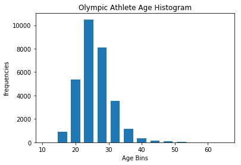

```python
# Let's check out the age of our athletes

bins = np.arange(10, df2['Age'].max()+1,4)

plt.hist(data = df2, x = 'Age', bins = bins, rwidth = .7);
plt.title('Olympic Athlete Age Histogram');
plt.xlabel('Age Bins');
plt.ylabel('frequencies');
```

The histogram shows us that most athletes fall between 20 and 30 years of age. The histogram is right skewed. The mode is less than the median. The median is less than the mean.

Our oldest competitor at 66 years of age was Louis Noverraz out of Switzerland. He got a silver medal in Sailing in the 1968 summer games in Mexico City.

There are ten athletes who competed at 13 years old. The U.S.A sent Donna de Varona the the 1960 Summer games in Roma. She won a gold medal in the swimming relay.

Height and Weight Info

It's a game of Inches and Pounds

The athletes have an average height of 69.9 inches, about 5.825 ft. The shortest athletes at came in at just under 54 inches(4ft 5 inches). All the athletes participated in gymnastics. Can you guess where our tallest athletes participate in the games? Duh...Basketball. The only player I'm familiar with standing at about 7 ft 5 inches is Arvydan Sebonis.

The average weight of our competitors is just under 163 pounds. The lightest athlete, Wang Xin, competing in diving and weighed about 62 pounds. The heaviest competitor, Chris Taylor is from the U.S. of A. He weight just over 401 pounds and competed in wrestling at the 1972 summer games in Munich.

I wonder what height and weight histograms look like?

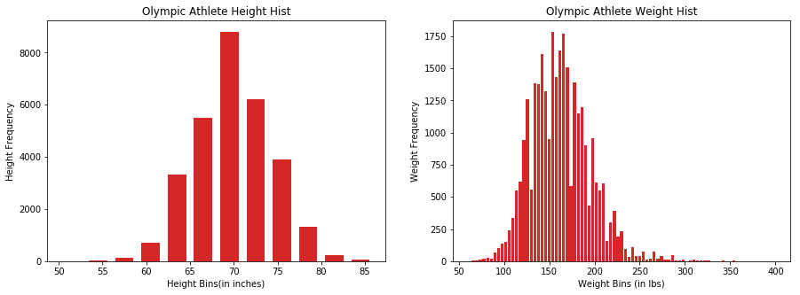

```python
# lets look at a subplot of height and weight characteristics of olympic athletes

height_bins= np.arange(50, df2['adjusted_height'].max()+1,3)
weight_bins= np.arange(60, df2['adjusted_weight'].max()+1,4)

f, axs =plt.subplots(2,2,figsize = (15,5))
sub_color = sns.color_palette()[3]

plt.subplot(1,2,1)

plt.hist(data = df2, x = 'adjusted_height', bins = height_bins, rwidth = .7, color = sub_color)
plt.title('Olympic Athlete Height Hist');
plt.xlabel('Height Bins(in inches)');
plt.ylabel('Height Frequency');

plt.subplot(1,2,2)
plt.hist(data = df2, x = 'adjusted_weight', bins = weight_bins, rwidth = .8, color = sub_color)
plt.title('Olympic Athlete Weight Hist');
plt.xlabel('Weight Bins (in lbs)');
plt.ylabel('Weight Frequency');
# Please Note that y-axis scales do not match
```

# team appearances

It looks like there are a total of 263 countries that have competed in the olympic games listed in the data set.

Hold up...arent there only 195 countries in the world?

Apparently, the International Olympic Committee (IOC) has a relaxed view of what a country is for competition purposes.

Check out this link if you'd like to read more: https://wonderopolis.org/wonder/how-many-countries-participate-in-the-olympics

What countries are frequently competing?

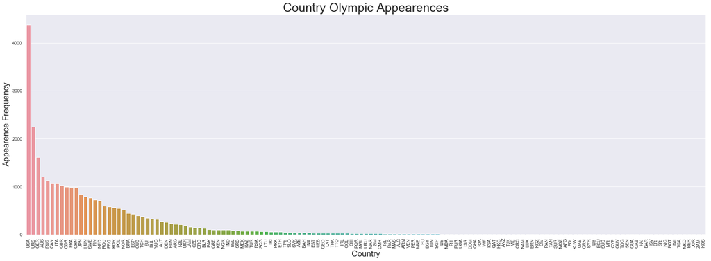

```python
# countplot of country appearences

sns.set(rc = {'figure.figsize':(30,10)});

sns.countplot(data = df2, x = 'NOC', order = df2['NOC'].value_counts().index);
plt.xticks(rotation = 90);
plt.xlabel('Country', size = 20)
plt.title('Country Olympic Appearences', size = 30);
plt.ylabel('Appearence Frequency', size = 20);
```

The U.S is the country most often seen in the games with 4273 appearances. The following is an appearance count of the next closest appearing countries and their associated counts:

Soviet Union-2203, Germany- 1518, Australia- 1196, Russia- 1091, Canada- 1024, Great Britain- 1010, Italy- 1008

How has country participation grown?

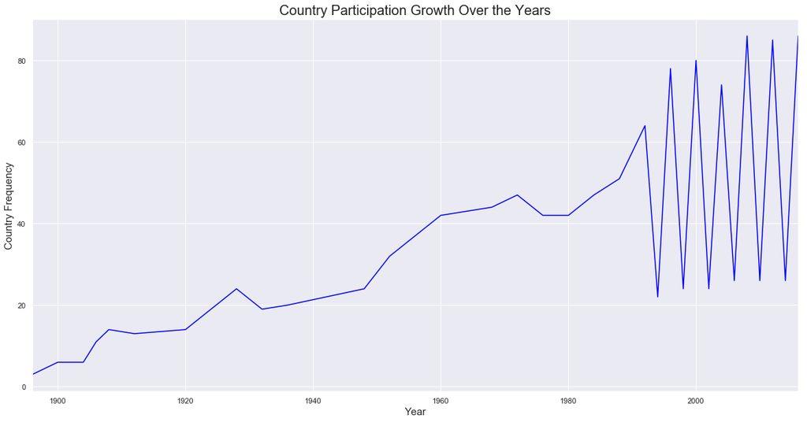

```python
plt.figure(figsize=(20,10))

yr_part = df2.groupby("Year")["NOC"].nunique()
yr_part.plot(kind = "line",color=('blue'));

plt.xticks(rotation = 0);
plt.ylabel('Country Frequency', size = 15);
plt.title('Country Participation Growth Over the Years', size = 20);
plt.xlabel('Year', size = 15);
```

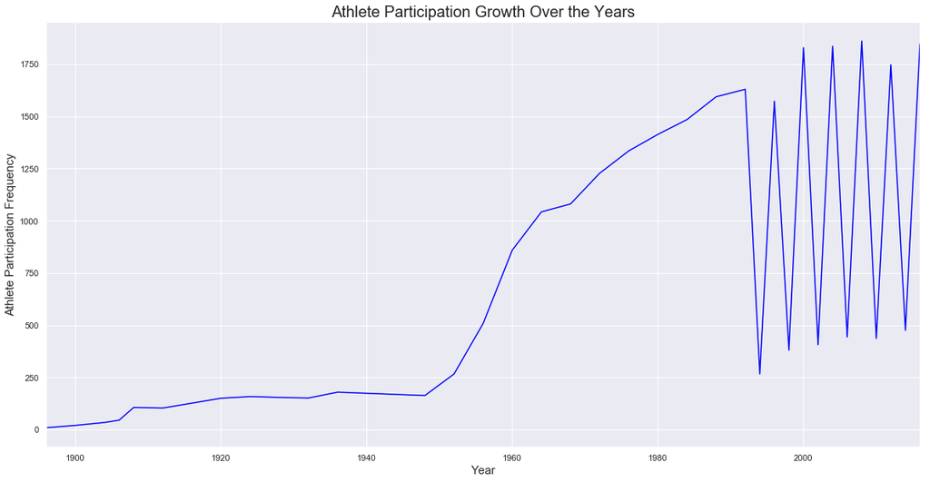

```python
plt.figure(figsize=(20,10))

gend_part = df2.groupby("Year")["ID"].nunique()
gend_part.plot(kind = "line",color=('blue'));


plt.xticks(rotation = 0);
plt.ylabel('Athlete Participation Frequency', size = 15);
plt.title('Athlete Participation Growth Over the Years', size = 20);
plt.xlabel('Year', size = 15);
```

Trophy Case and Country Participation

What kind of hardware has the U.S. taken home?

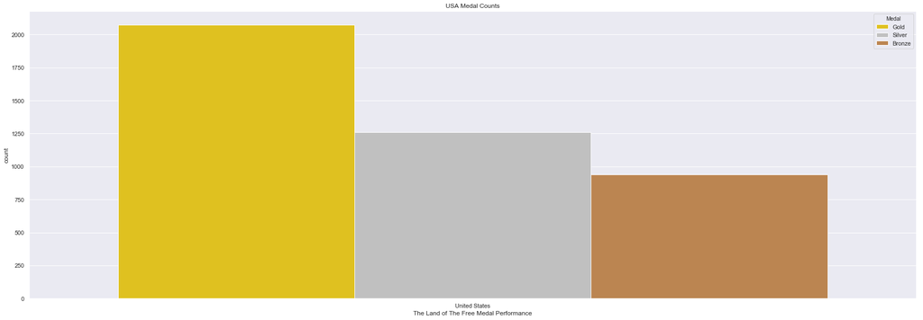

```python
# USA medal performance
#sns.countplot(data =df2, x= )

coloro = ['Gold', 'Silver', 'Peru']

USA = df2.query('Team == "United States"');

sns.countplot(data = USA, x = 'Team',  hue = 'Medal', palette = coloro);
plt.title('USA Medal Counts');
plt.xlabel('The Land of The Free Medal Performance');
```

Check out USA's medal performance. Not to shabby. The sweet land of liberty has over 2000 gold medals, 1250 Silver medals, and almost 1000 bronze medals.

What countries are sending the most athletes to compete?

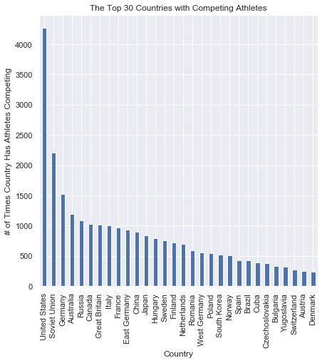

```python
# Lets take a look at the countries most often competing
country_count = df2['Team'].value_counts().sort_values(ascending = False)
sns.set(rc = {'figure.figsize':(7,7)})
color = sns.color_palette()[0]
country_count.iloc[:30].plot(kind = 'bar', color = color);
plt.title('The Top 30 Countries with Competing Athletes');
plt.xlabel('Country');
plt.ylabel('# of Times Country Has Athletes Competing');
```

The chart helps to visually convey athletes per country in olympic appearences. The graph is limited to the top 30 countries.

Well....The Good Ole US of A sends the most athletes to the games. Merica!!!!

Denmark falls into the 30th spot.

Who are the top medal winning countries?

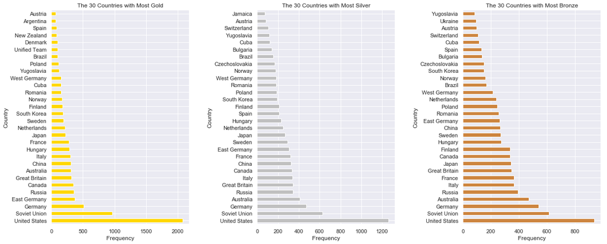

```python
# Lets look at medals per country

Medal_Gold = df2[df2['Medal'] == 'Gold'].groupby('Team')['Medal'].count().sort_values(ascending = False)
Medal_Silver = df2[df2['Medal'] == 'Silver'].groupby('Team')['Medal'].count().sort_values(ascending = False)
Medal_Bronze = df2[df2['Medal'] == 'Bronze'].groupby('Team')['Medal'].count().sort_values(ascending = False)

f, axs =plt.subplots(2,2,figsize = (20,8))
plt.subplots_adjust(wspace=.4935)

plt.subplot(1,3,1)
Medal_Gold.iloc[:30].plot(kind = 'barh', color = 'gold');
plt.title('The 30 Countries with Most Gold')
plt.xlabel('Frequency');
plt.ylabel('Country');

plt.subplot(1,3,2)
Medal_Silver.iloc[:30].plot(kind = 'barh', color = 'silver');
plt.title('The 30 Countries with Most Silver')
plt.xlabel('Frequency');
plt.ylabel('Country');

plt.subplot(1,3,3)
Medal_Bronze.iloc[:30].plot(kind = 'barh', color = 'peru');
plt.title('The 30 Countries with Most Bronze')
plt.xlabel('Frequency');
plt.ylabel('Country');
```

The U.S. dominates in Gold, Silver and Bronze Medals. The Soviet Union and Germany are second in third in all respective medal categories.  
Other notable countries include Australia and Russia. I'd be curious to see the break down between Summer and Winter Games.

Athlete Performance

Who are the best athletes?

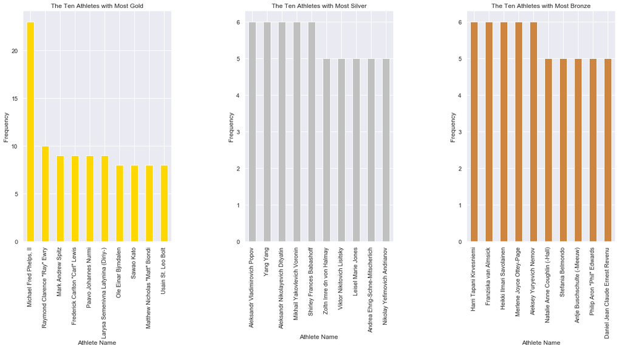

```python
#Athlete Dominance

Athlete_Gold = df2[df2['Medal'] == 'Gold'].groupby('Name')['Medal'].count().sort_values(ascending = False)
Athlete_Silver = df2[df2['Medal'] == 'Silver'].groupby('Name')['Medal'].count().sort_values(ascending = False)
Athlete_Bronze = df2[df2['Medal'] == 'Bronze'].groupby('Name')['Medal'].count().sort_values(ascending = False)
f, axs =plt.subplots(2,2,figsize = (20,8))
#plt.subplots_adjust(hspace = 0.8)

plt.subplots_adjust(wspace=.4935)
plt.subplot(1,3,1)
Athlete_Gold.iloc[:10].plot(kind = 'bar', color = 'gold');
plt.title('The Ten Athletes with Most Gold')
plt.xlabel('Athlete Name');
plt.ylabel('Frequency');

plt.subplot(1,3,2)
Athlete_Silver.iloc[:10].plot(kind = 'bar', color = 'silver');
plt.title('The Ten Athletes with Most Silver')
plt.xlabel('Athlete Name');
plt.ylabel('Frequency');

plt.subplot(1,3,3)
Athlete_Bronze.iloc[:10].plot(kind = 'bar', color = 'peru');
plt.title('The Ten Athletes with Most Bronze')
plt.xlabel('Athlete Name');
plt.ylabel('Frequency');
#note y index are not equal
```

Micheal Phelps has won the most gold medals. He's a house hold name because he has 23 gold medals. Is it safe to say Micheal reminds me of a younger me? I know you'll agree!

The other guy I recognize...Usain Bolt! I retract my last statement. I'm more of a combination of Michael and Usain.

Familiar Faces

Which atletes compete the most often?

```python
# The top twenty five olympic participants

df2.Name.value_counts()[:25]
```

```
Michael Fred Phelps, II                            28
Larysa Semenivna Latynina (Diriy-)                 18
Nikolay Yefimovich Andrianov                       15
Borys Anfiyanovych Shakhlin                        13
Ole Einar Bjrndalen                                13
Takashi Ono                                        13
Aleksey Yuryevich Nemov                            12
Dara Grace Torres (-Hoffman, -Minas)               12
Jennifer Elisabeth "Jenny" Thompson (-Cumpelik)    12
Paavo Johannes Nurmi                               12
Natalie Anne Coughlin (-Hall)                      12
Ryan Steven Lochte                                 12
Birgit Fischer-Schmidt                             12
Sawao Kato                                         12
Vra slavsk (-Odloilov)                             11
Matthew Nicholas "Matt" Biondi                     11
Aleksandr Vladimirovich Popov                      11
Mark Andrew Spitz                                  11
Aleksandr Nikolayevich Dityatin                    10
Yang Yang                                          10
Akinori Nakayama                                   10
Vitaly Venediktovich Shcherbo                      10
Frederick Carlton "Carl" Lewis                     10
Aladr Gerevich (-Gerei)                            10
Raisa Petrovna Smetanina                           10
Name: Name, dtype: int64
```

Michael Phelps has competed 28 times. The next closest athlete stands at 18. I recognize Ryan Lochte with 12 appearances and Carl Lewis with 10.

## Host Cities

Now that we have seen the top 30 countries in the Olympics...Lets look at host Cities.

It looks like there are 42 different cities that have hosted the Olympics.

Anytime Anywhere

What cities have hosted the most athletes?

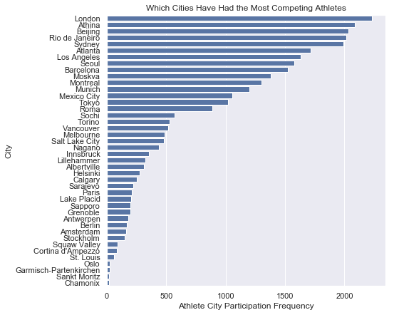

```python
## Lets look at what cities have the most athletes competing.

city_color = sns.color_palette()[0]
city_order = df2['City'].value_counts().index
sns.countplot(data = df2, y ='City', color = city_color, order = city_order);
plt.title('Which Cities Have Had the Most Competing Athletes');
plt.ylabel('City');
plt.xlabel('Athlete City Participation Frequency');
```

Out of the 42 cities competing, London has hosted the most athletes. Chamonix, the least.

## Athlete Gender Participation

What does gender participation look like?

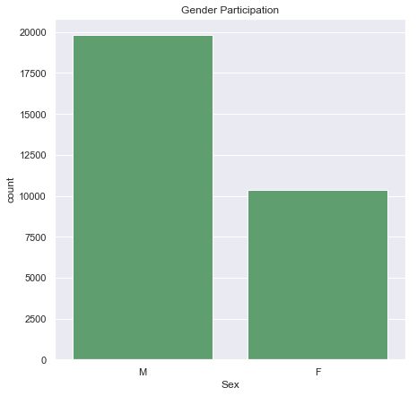

```python
sex_color = sns.color_palette()[2]

sex_order = df2['Sex'].value_counts().index

sns.countplot(data = df2, x ='Sex', color = sex_color, order = sex_order);
plt.title('Gender Participation');
```

From the period of 1896 to 2016, Male participants total 19,831 and Female participants total 10,350.

Please note, the statement only includes complete data within the data set. NaN values for Gender values were omitted from results.

# Bivariate Exploration

Is there any correlation within our variables?

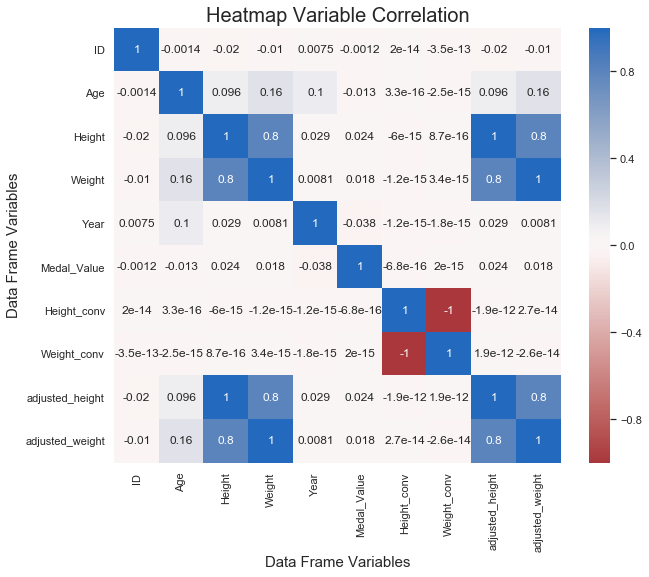

```python
correlation = df2.corr()

plt.subplots(figsize = (10,8))
sns.heatmap(correlation, annot = True, cmap = 'vlag_r');

plt.title('Heatmap Variable Correlation', size = 20);
plt.xlabel('Data Frame Variables', size = 15);
plt.ylabel('Data Frame Variables', size = 15);
```

The heatmap helps to identify correlations between the variables. You can see that adjusted height and weight have a strong positive correlation.

However, our variable of interest, Medal(coded in Medal Value) has no real strong correlations to any other variable.

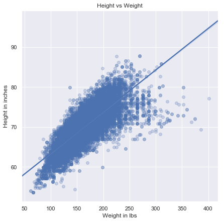

```python
# Lets look at the plot between height and weight.  This ties back into the correlation within the heatmap above.

sns.regplot(data = df2, x = 'adjusted_weight', y = 'adjusted_height',
            x_jitter = .03, y_jitter = .03, scatter_kws = {'alpha': 1/4});
plt.title('Height vs Weight');
plt.xlabel('Weight in lbs');
plt.ylabel('Height in inches');
```

There is a strong positive relationship between height and weight. This verifies the correlation output between the two in the heatmap above.

## Athlete Weight, Height, Time, etc...

Are athletes getting bigger faster stronger?

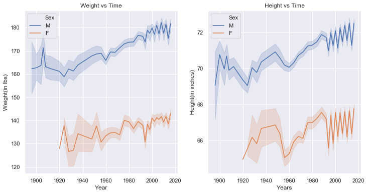

```python
# Have athletes gotten heavier over the years?
# Have athletes gotten taller over the years?

f,axs = plt.subplots(2,2, figsize = (12,6))

plt.subplot(1,2,1)
sns.lineplot(data = df2, x = 'Year', y = 'adjusted_weight', hue = 'Sex');
plt.title('Weight vs Time')
plt.xlabel('Year')
plt.ylabel('Weight(in lbs)')

plt.subplot(1,2,2)
sns.lineplot(data = df2, x = 'Year', y = 'adjusted_height', hue = 'Sex');
plt.title('Height vs Time');
plt.xlabel('Years');
plt.ylabel('Height(in inches)');
```

The graph on the left depicts Olympian Weight over the span of time from 1896 through 2016. The graph is seperated by male and female weights.  
Both genders have trended upwards over time in weight. It would be interesting to look at the specific weights within each event.

The graph on the right depicts Olympian Height over the span of time from 1896 through 2016. The graph is seperated by male and female heights.  
Height mirrors the weight graph in the sense that height is trending upwards.

Women were able to compete in the olympics in 1900. Our data set includes data for women dating back to 1920.

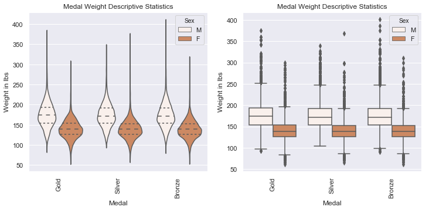

```python
# Medals and Weight Histogram and Violin Plot Per Gender

medal_body_color = sns.color_palette()[1]

plt.figure(figsize = [12,5])

plt.subplot(1,2,1)
ax1 = sns.violinplot(data = df2, x = 'Medal', y = 'adjusted_weight', hue = 'Sex', color = medal_body_color, inner = 'quartile');
plt.xticks(rotation = 90);
plt.ylabel('Weight in lbs')
plt.title('Medal Weight Descriptive Statistics');

plt.subplot(1,2,2)
ax1 = sns.boxplot(data = df2, x = 'Medal', y = 'adjusted_weight', hue = 'Sex', color = medal_body_color);
plt.xticks(rotation = 90);
plt.ylabel('Weight in lbs');
plt.title('Medal Weight Descriptive Statistics');
```

Want that Gold... If you're a male, your golden opportunity lies somewhere in between 150 and 200 lbs.  
If you're a female, your golden opportunity lies somewhere in between 130 and 155 lbs.

If you ain't first, you're last(TM. Ricky Bobby). No need to discuss Silver or Bronze.

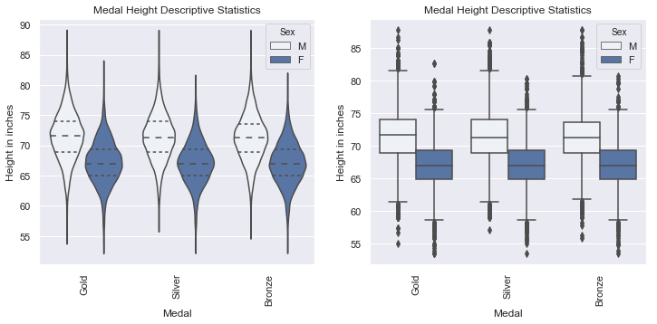

```python
# Medals and Height Histogram and Violin Plot Per Gender

medal_body_color = sns.color_palette()[0]

plt.figure(figsize = [12,5])

plt.subplot(1,2,1)
ax1 = sns.violinplot(data = df2, x = 'Medal', y = 'adjusted_height', hue = 'Sex', color = medal_body_color, inner = 'quartile');
plt.xticks(rotation = 90);
plt.ylabel('Height in inches');
plt.title('Medal Height Descriptive Statistics');

plt.subplot(1,2,2)
ax1 = sns.boxplot(data = df2, x = 'Medal', y = 'adjusted_height', hue = 'Sex', color = medal_body_color);
plt.xticks(rotation = 90);
plt.ylabel('Height in inches');
plt.title('Medal Height Descriptive Statistics');
```

If you're a female, you're olympic dreams have a better shot at fruition between 65 and 68 inches(5'4" and 5'7")

BMI coming into play...

BMI is used to broadly define different weight groups. The same groups apply to both men and women.

Underweight: BMI is less than 18.5 Normal weight: BMI is 18.5 to 24.9 Overweight: BMI is 25 to 29.9 Obese: BMI is 30 or more

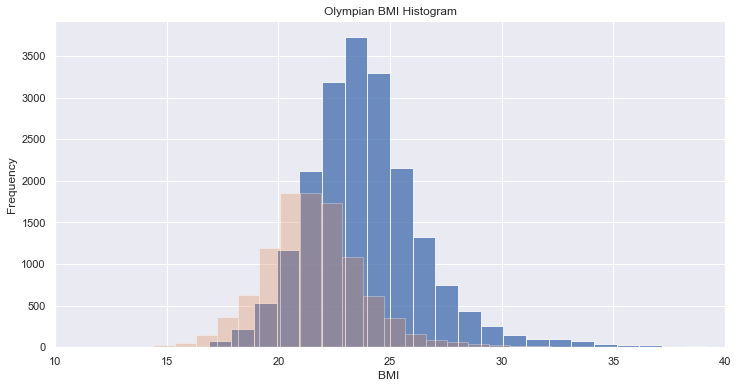

```python
sns.set()
plt.figure(figsize=(12,6))

df2[df2['Sex']=='M']['BMI'].plot(kind='hist',alpha=.8,bins=40)
df2[df2['Sex']=='F']['BMI'].plot(kind='hist',alpha=.3,bins=40)
plt.title('Olympian BMI Histogram');
plt.xlabel('BMI ');
plt.xlim(10,40);
```

The median female BMI is 21. The average Female BMI is 22 The median and average male BMI both come in at 24.

I wonder what the changes in BMI look like over time?

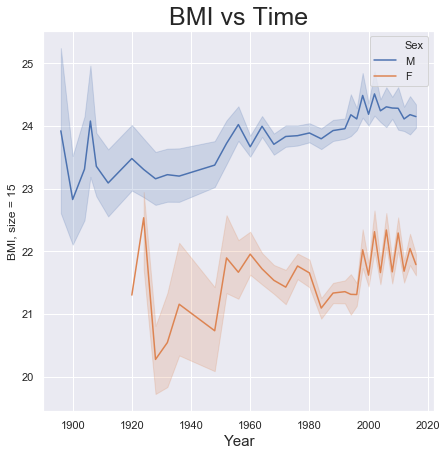

```python
#BMI and Time

sns.lineplot(data = df2, x = 'Year', y = 'BMI', hue = 'Sex');
plt.title('BMI vs Time', size = 25);
plt.xlabel('Year', size = 15);
plt.ylabel('BMI, size = 15');
```

The graph shows what the BMI index for male and female athletes looks like over time.

Men seem to be trending downward after a peak in the early 2000's

Women are also trending downward. Women BMI peaked early into women competition, sometime between 1920 and 1930.

However, it does look like BMI has increased for both if we date back to early competition.

Age is just a number.

I wonder what age looks like for competitors? Lets check out the breakdown between gender age

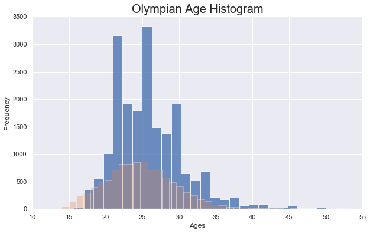

```python
# What do the ages of competing olympians look like?
sns.set()
plt.figure(figsize=(10,6))
df2[df2['Sex']=='M']['Age'].plot(kind='hist',alpha=.8,bins=40)
df2[df2['Sex']=='F']['Age'].plot(kind='hist',alpha=.3,bins=40)
plt.title('Olympian Age Histogram', size = 20);
plt.xlabel('Ages');
plt.xlim(10,55);
```

The Male Olympian Median Age is: 25 The average Male age is: 26

The Female Olympian Median Age is: 24 The average Female age is: 25

Sport Participation

What are the most popular sports per gender?

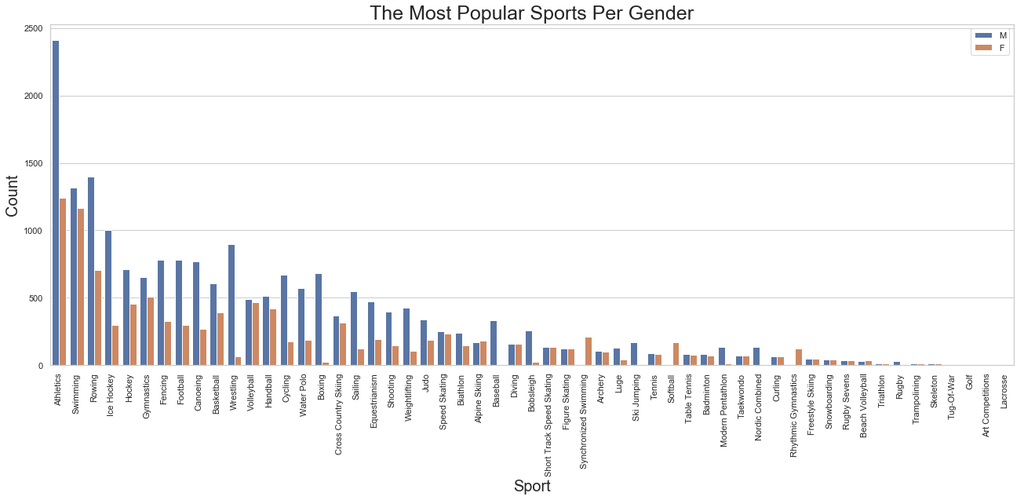

```python
# What are the most popular sports per gender

plt.figure(figsize = [22, 8])

sport_order = df2['Sport'].value_counts().index

sns.set_style('whitegrid')

sns.countplot(data = df2, x = 'Sport', hue = 'Sex', order = sport_order);
plt.xticks(rotation = 90);
plt.title('The Most Popular Sports Per Gender', size = 25)
plt.xlabel('Sport', size = 20)
plt.ylabel('Count', size = 20)
plt.legend(loc = 1);
```

Looks like Athletics is the clear favorite. Although, I'm not really sure what it encompasses. I'm assuming it has something to do with track and field events. Swimming, rowing, and gymnastics seem to be pretty popular.

I didn't know tug of war was an olympic sport.

It doesn't look like Im good at anything on this list...darnit!!! I guess I'll just keep watching on T.V.

Sport Popularity per Season

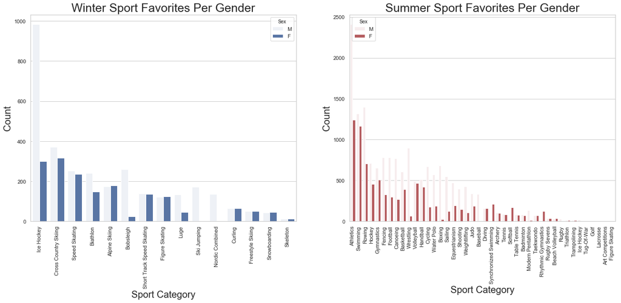

```python
# What are the most popular sports per Season per Gender
winter_games =df2.query('Season == "Winter"');

winter_color = sns.color_palette()[0]
winter_order = winter_games['Sport'].value_counts().index

summer_games = df2.query('Season == "Summer"');
summer_order = summer_games['Sport'].value_counts().index
summer_color = sns.color_palette()[3]

plt.figure(figsize = [22, 8])

plt.subplot(1,2,1)
sns.countplot(data = winter_games, x = 'Sport', hue = 'Sex', color = winter_color, order = winter_order);
plt.title('Winter Sport Favorites Per Gender', size = 25);
plt.xticks(rotation = 90);
plt.xlabel('Sport Category', size =20);
plt.ylabel('Count', size = 20);

plt.subplot(1,2,2)
sns.countplot(data = summer_games, x = 'Sport', hue = 'Sex', color = summer_color, order = summer_order);
plt.title('Summer Sport Favorites Per Gender', size = 25);
plt.xticks(rotation = 90);
plt.xlabel('Sport Category', size =20);
plt.ylabel('Count', size = 20);
```

Looks like Ice hockey takes the cake when the temperature drops. Cross country skiing does not sound fun, but hey, to each their own. Speed skating looks to have somewhat equal participation between men and women.

# Multivariate Exploration

What do size comparison of BMI against height and weight look like?

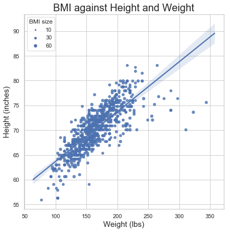

```python
# Height Weight and BMI w size

#sample used to improve readability
sample = np.random.choice(df2.shape[0], 8000, replace = False)
df2_sample = df2.loc[sample]

sns.regplot(data = df2_sample, x = 'adjusted_weight', y = 'adjusted_height',
           x_jitter = .08, scatter_kws = {'s': df2['BMI']});

plt.xlabel('Weight (lbs)', size = 15);
plt.ylabel('Height (inches)', size = 15);
plt.title('BMI against Height and Weight', size = 20);
sizes = [10, 30, 60]
colored = sns.color_palette()[0]
legend_obj = []

for s in sizes:
    legend_obj.append(plt.scatter([],[],s = s/2, color = colored))
plt.legend(legend_obj, sizes, title = 'BMI size');
```

The above graph is easily understandable, but vaguely interpretable. BMI is correlated to height and weight. The larger each variable is, the larger your BMI.

Let's use color.

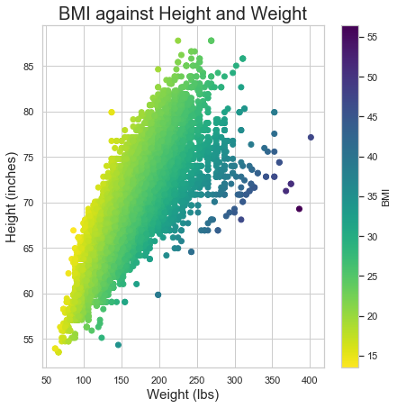

```python
#BMI against height and weight w color

plt.scatter(data = df2, x = 'adjusted_weight', y = 'adjusted_height', c  = 'BMI', cmap = 'viridis_r');
# alpha = 1/3 if I wanted to make the points translucent.
plt.colorbar(label = 'BMI');
plt.xlabel('Weight (lbs)', size = 15);
plt.ylabel('Height (inches)', size = 15);
plt.title('BMI against Height and Weight', size = 20);
```

Using color for BMI instead of size makes the graph much easier to interpret in my opinion. The darker the color, the higher the BMI.

A sample set of the data was not used so that the full effect of the data can be taken into account.

What do medal chances look like against age and BMI?

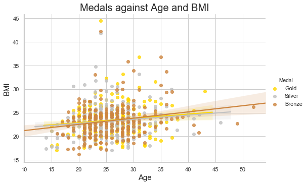

```python
# Age vs BMI and Medals
#medal was made a categorical variable towards the top of the notebook
hue_order  = ['Gold', 'Silver', 'Peru']
g = sns.FacetGrid(data = df2_sample, hue = 'Medal',
                 height = 5, aspect = 1.5, palette = coloro);
g = g.map(sns.regplot, 'Age', 'BMI', x_jitter = .04);
g.add_legend();
plt.xlabel('Age', size = 15);
plt.ylabel('BMI', size = 15);
plt.title('Medals against Age and BMI', size = 20);
```

The graph depicts your chances of winning a medal against age and BMI.

Do height and weight body compositions matter per Olympic game seasons?

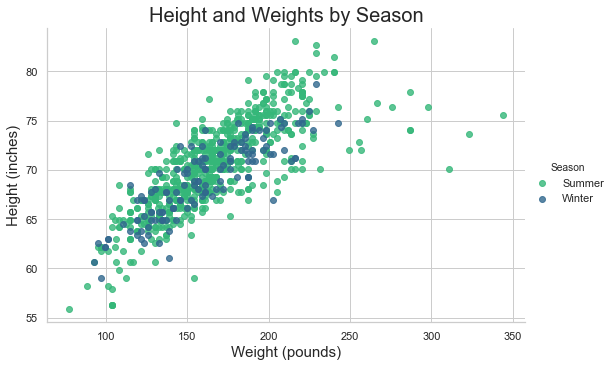

```python
hue_order  = ['Gold', 'Silver', 'Peru']
g = sns.FacetGrid(data = df2_sample, hue = 'Season',
                 height = 5, aspect = 1.5, palette = 'viridis_r');
g = g.map(sns.regplot, 'adjusted_weight', 'adjusted_height', x_jitter = .04, fit_reg = False);

g.add_legend();
plt.xlabel('Weight (pounds)', size = 15);
plt.ylabel('Height (inches)', size = 15);
plt.title('Height and Weights by Season', size = 20);
```

The winter athlete average weight: 160 The winter athlete average height: 69

The summer athlete average weight: 163 The summer athlete average height: 70

The graph above looks at a sample of athlete height and weight per season. Once averages come into play, there is not too much difference in the body composition as a whole between summer and winter athletes.

The funny thing is I would have guessed winter athletes as being heavier. God knows I always put on a few pounds during colder months. However, winter athletes ended up being lighter...if ever so slightly.

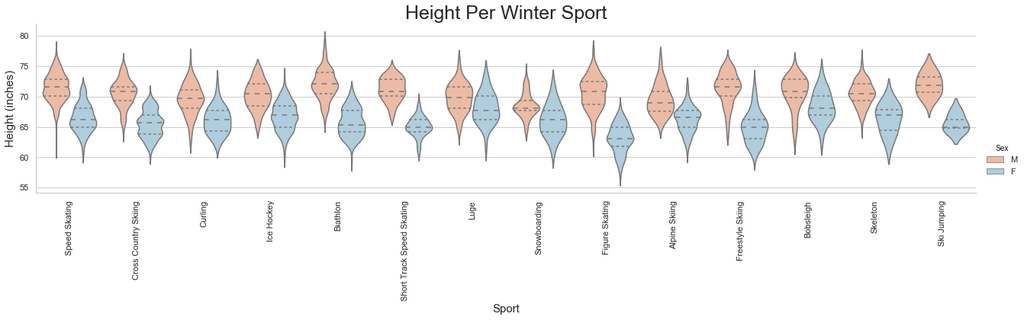

```python
# Winter Athlete Sport Characteristics

ordered = winter_weight.adjusted_height.value_counts().index
c = sns.FacetGrid(data = winter_weight, hue = 'Sex',
                 height = 4,aspect = 4.5, palette = 'viridis');
c = c.map(sns.violinplot, 'Sport', 'adjusted_height','Sex', inner = 'quartile', hue_order = ['M','F'], order = None,
         palette = 'RdBu');
c.add_legend()
plt.xlabel('Sport', size = 15);
plt.ylabel('Height (inches)', size = 15);
plt.title('Height Per Winter Sport', size = 25);
plt.xticks(rotation = 90);
```

The above graph shows height characteristics for the different Winter Sports.

I thought it was interesting to see how close gender height characteristics are in luge.

Height discrepencies are associated with the Biathlon, Figure Skating and Ski Jumping.

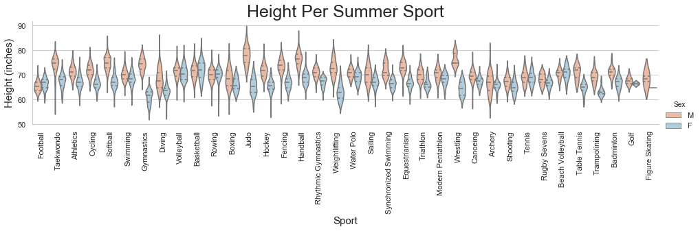

```python
#summer athlete sport characteristics

c = sns.FacetGrid(data = summer_weight, hue = 'Sex',
                 height = 3,aspect = 4.5, palette = 'viridis_r');
c = c.map(sns.violinplot, 'Sport',  'adjusted_height', 'Sex', inner = 'quartile', hue_order = ['M','F'], order = None,
         palette = 'RdBu');
c.add_legend()
plt.xlabel('Sport', size = 15);
plt.ylabel('Height (inches)', size = 15);
plt.title('Height Per Summer Sport', size = 25);
plt.xticks(rotation = 90);
```

There are clearly more sports in the Summer games. The above violin plot shows height characteristics of Summer athletes.

Wrestling, Weight Lifting, Judo, Archery and Diving are a few of the larger gender height discrepencies.

Gender characteristics for Volleybal, Water Polo and Modern Pentathlon athletes are very similar...interesting!

Can we look at age and BMI via shape?

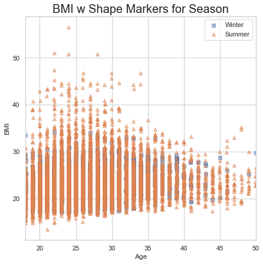

```python
# age and bmi per season via shape...

cat_markers = [['Winter', 's'], ['Summer', '^']]
for cat, markers in cat_markers:
    plot_data = df2.loc[df2['Season'] == cat]
    sns.regplot(data = plot_data, x = 'Age', y = 'BMI', x_jitter = .04, fit_reg = False, marker = markers, scatter_kws={'alpha':0.5})
plt.xlabel('Age');
plt.xlim(18,50)
plt.ylabel('BMI');
plt.legend(['Winter', 'Summer']);
plt.title('BMI w Shape Markers for Season', size = 20);
```

Using shape to determine BMI differences between the summer and winter games may not be our best choice. It's hard to get a read on each.

Regardless, shapes are stacked on top of one another most frequent within the 20 and 30 BMI range.

Can we look at detailed characteristics of medal winners per gender and season?

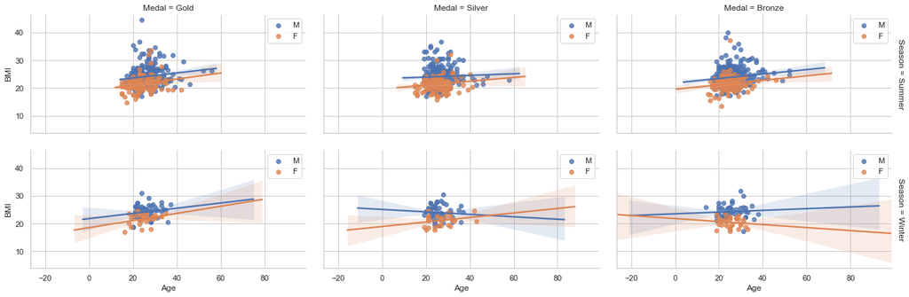

```python
# lets break down age and BMI even further per medal, per gender and per season
#hue and row are interchangeable...

sample2 = np.random.choice(df2.shape[0], 16000, replace = False);
df2_sample2 = df2.loc[sample2];

f = sns.FacetGrid(data = df2_sample2, col = 'Medal', row ='Season', hue = 'Sex', margin_titles = True, aspect = 2)
f.map(sns.regplot, 'Age', 'BMI');

for ax in f.axes.ravel():
    ax.legend()
```

Regplot of a sample of competitor performance and medals awarded for age and BMI.

Male's tend to have larger BMI's than female for most age ranges.

BMI's tend to be higher for both genders in the Summer games.

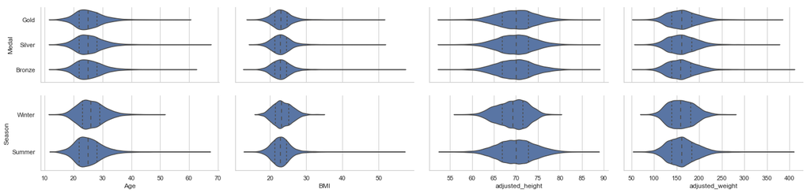

```python
#plot matrix
p = sns.PairGrid(data = df2, x_vars = ['Age', 'BMI', 'adjusted_height', 'adjusted_weight'], y_vars = ['Medal', 'Season'], aspect = 2);
p.map(sns.violinplot, inner = 'quartile');
```

The plot matrix presents side by side medal and season charactersitics for age, BMI, height, and weight.

You can quickly notice that Summer athletes may compete at older stages in their lives. BMI's and weight tend to also be higher in the Summer Season.

The characteristics for medal placement are not too different from one another.

I hope you found this exploration as interesting as I did. I better start practicing and perfecting my skills for the next games.

I'm going for Gold!